# MSEIRV Model Policy Visualizer

### Data Cleaning Functions

The following function acts as a file reader:

```r
file_reader <- function(type, trigger, mu, std, sim_num, campaign=FALSE) {
  if (campaign==TRUE) {
    name <- paste0(paste0(paste0("campaigns", paste0("_mu", mu*100)), paste0("_std", std*100)), paste0("_sim", sim_num))
    dir <- paste0("policy_sims/", paste0(type, "/"))
    if (trigger != "none")
      dir <- paste0(dir, paste0(trigger, "/"))
    my_data <- readRDS(paste0(dir, name))
  }
  else {
    name <- paste0(paste0(paste0("sim", paste0("_mu", mu*100)), paste0("_std", std*100)), paste0("_sim", sim_num))
    dir <- paste0("policy_sims/", paste0(type, "/"))
    if (trigger != "none")
      dir <- paste0(dir, paste0(trigger, "/"))
    my_data <- readRDS(paste0(dir, name))
  }
  return(my_data)
}
```

The following function retrieves a matrix of all the time series of cumulative case burdens under each condition:

```r
time_series_cum_sum_stats <- function(type, trigger, mu, std, total_sims=100) {
  dem_list <- readRDS("Parameterization/dem_list")
  disease_list <- readRDS("Parameterization/disease_list")
  province_data <- readRDS("Parameterization/disease_list")$province_data

  # retrieves the columns of time series for a particular disease class
  stages <- nrow(dem_list$age_buckets)
  classes <- 6
  regions <- ncol(disease_list$v)
  get_class <- function(time.series, class_number) {
    tmp <- time.series[, -1]
    return(tmp[, (stages*(class_number - 1)+1):(stages*class_number)])
  }

  # retrieves the time seires of cumulative case burden
  get_case_burden <- function(some_sim) {
    name <- paste0(paste0(paste0("sim", paste0("_mu", mu*100)), paste0("_std", std*100)), paste0("_sim", some_sim))
    dir <- paste0("policy_sims/", paste0(type, "/"))
    if (trigger != "none")
      dir <- paste0(dir, paste0(trigger, "/"))
    sim <- readRDS(paste0(dir, name))

    time <- sim[[1]][, 1]/(365/7)
    I <- do.call(cbind, purrr::map(sim, function(x) rowSums(get_class(x, 4))))
    tot_I <- rowSums(I)
    tot_I[1:52] <- 0
    cum_tot_I <- cumsum(tot_I)
    return(cum_tot_I)
  }
  all_time_series <- do.call(cbind, purrr::map(1:total_sims, function(x) get_case_burden(x)))
  name1 <- paste0(paste0(paste0("_cumcaseburden", paste0("_mu", mu*100)), paste0("_std", std*100)))
  if (trigger != "none")
    name2 <- paste0(paste0(type, "_"), trigger)
  else
    name2 <- paste0(type, "_")
  name <- paste0(name2, name1)
  saveRDS(all_time_series, paste0("policy_sims_sum_stats/", name))
}
```

The following function computes the cumulative case burden, number of TCs and number of cases averted for each sim:

```r
get_case_TC_summary <- function() {
  get_sim_summary <- function(type, trigger) {
    get_ind_sim_summary <- function(mu, std, sim_num) {
      # set up
      dem_list <- readRDS("Parameterization/dem_list")
      disease_list <- readRDS("Parameterization/disease_list")
      province_data <- readRDS("Parameterization/disease_list")$province_data
      stages <- nrow(dem_list$age_buckets)
      classes <- 6
      regions <- ncol(disease_list$v)

      # read in simulations
      sims <- file_reader(type, trigger, mu, std, sim_num)

      # retrieves the columns of time series for a particular disease class
      get_class <- function(time.series, class_number) {
        tmp <- time.series[, -1]
        return(tmp[, (stages*(class_number - 1)+1):(stages*class_number)])
      }

      # compute cumulative cases
      compute_cum_cases <- function(some_sims) {
        I <- do.call(cbind, purrr::map(some_sims, function(x) rowSums(get_class(x, 4))))
        tot_I <- rowSums(I)
        tot_I[1:(1*52)] <- 0
        cum_tot_I <- tail(cumsum(tot_I), 1)
      }
      cum_cases <- compute_cum_cases(sims)

      # compute the number of TCs
      compute_number_TCs <- function() {
        if (type=="routine")
          return(0)

        campaigns <- file_reader(type, trigger, mu, std, sim_num, campaign = TRUE)
        tmp_campaign_count <- unlist(campaigns)
        tmp_campaign_count <- length(tmp_campaign_count[which(tmp_campaign_count > 52)])
        return(tmp_campaign_count)
      }
      number_TCs <- compute_number_TCs()

      df <- data.frame(cum_cases=cum_cases, number_TCs=number_TCs)
      return(df)
    }
    input_mat <- readRDS("Parameterization/initialization_sims/input_mat")
    input_mat2 <- readRDS("Parameterization/initialization_sims/input_mat2")
    input_mat <- rbind(input_mat, input_mat2)
    df <- parallel::mcmapply(get_ind_sim_summary, input_mat[, 1], input_mat[, 2], input_mat[, 3], mc.cores=detectCores()) %>%
      t() %>%
      as.data.frame() %>%
      cbind(input_mat, .) %>%
      cbind(data.frame(type=rep(type, nrow(.)), trigger=rep(trigger, nrow(.))), .)
    return(df)
  }
  input <- data.frame(type=c("routine", "case_trigger", "case_trigger", "case_trigger", "sero_trigger", "sero_trigger"),
                      trigger=c("none", "N_15", "N_25", "N_50", "sus_10", "sus_15"))
  df <- do.call(rbind, purrr::map(1:nrow(input), function(x) get_sim_summary(type=input[x, 1], trigger=input[x, 2])))

  # compute the cases averted
  routine_cum_cases <- df %>%
    filter(type=="routine") %>%
    arrange(-desc(mu), -desc(std), -desc(sim_num)) %>%
    pull(cum_cases) %>%
    unlist()

  compute_cases_averted <- function(some_type, some_trigger) {
    cum_cases <- df %>%
      filter(type==some_type) %>%
      filter(trigger==some_trigger) %>%
      arrange(-desc(mu),-desc(std), -desc(sim_num)) %>%
      pull(cum_cases) %>%
      unlist()

    cases_averted <- routine_cum_cases-cum_cases
    return(cases_averted)
  }
  all_cases_averted <- unlist(purrr::map(1:(nrow(input)), function(x) compute_cases_averted(input[x, 1], input[x, 2])))
  df <- cbind(df, cases_averted=all_cases_averted)
  saveRDS(df, "policy_sims_sum_stats/cases_averted_sum_stats")
}
```

The following function computes the provinces level summary data under each scenario:

```r
get_province_summary <- function(region){
  # set up
  dem_list <- readRDS("Parameterization/dem_list")
  disease_list <- readRDS("Parameterization/disease_list")
  province_data <- readRDS("Parameterization/disease_list")$province_data
  stages <- nrow(dem_list$age_buckets)
  classes <- 6
  regions <- ncol(disease_list$v)
  r <- which(province_data$province == region)

  # retrieves the columns of time series for a particular disease class
  get_class <- function(time.series, class_number) {
      tmp <- time.series[, -1]
      return(tmp[, (stages*(class_number - 1)+1):(stages*class_number)])
  }

  # get province data for each sim
  get_province_data <- function(type, trigger, mu, std, sim_num) {
    sim <- file_reader(type, trigger, mu, std, sim_num)[[r]]

    # cumulative cases
    I <- rowSums(get_class(sim, 4))
    I[1:(5*52)] <- 0
    cum_I <- tail(cumsum(I), 1)

    # number TCs
    if (type=="routine")
      num_TCs <- 0
    else {
      campaigns <- file_reader(type, trigger, mu, std, sim_num, campaign=TRUE)[[r]]
      campaigns <- campaigns[which(campaigns > 5*52)]
      num_TCs <- length(campaigns)
    }
    df <- data.frame(cum_I=cum_I, num_TCs=num_TCs)
    return(df)
  }
  input_scenarios <- data.frame(type=c("routine", "case_trigger", "case_trigger", "case_trigger", "sero_trigger", "sero_trigger"),
                           trigger=c("none", "N_15", "N_25", "N_50", "sus_10", "sus_15"))
  input_mat <- readRDS("Parameterization/initialization_sims/input_mat")
  input_mat2 <- readRDS("Parameterization/initialization_sims/input_mat2")
  input_mat <- rbind(input_mat, input_mat2)

  input <- do.call(rbind, purrr::map(1:nrow(input_scenarios), function(x) cbind(rep(input_scenarios[x, 1], nrow(input_mat)),
                                                                                rep(input_scenarios[x, 2], nrow(input_mat)),
                                                                                input_mat)))
  df <- parallel::mcmapply(get_province_data, input[, 1], input[, 2],
                           input[, 3], input[, 4], input[, 5], mc.cores=detectCores()) %>%
    t() %>%
    data.frame() %>%
    cbind(input, .) %>%
    setNames(c("type", "trigger", "mu", "std", "sim_num", "cum_I", "num_TCs"))

  name <- paste0("summary_stats_", region)
  saveRDS(df, paste0("policy_sims_sum_stats/", name))
  print(df)
}
```

### Visualization Functions

The following function plots the typical time-series of incidence for three vaccination scenarios in a given scenario:

```r
library(patchwork)
typical_incidence_plot <- function(mu, std) {
  dem_list <- readRDS("Parameterization/dem_list")
  disease_list <- readRDS("Parameterization/disease_list")
  province_data <- readRDS("Parameterization/disease_list")$province_data

  # retrieves the columns of time series for a particular disease class
  stages <- nrow(dem_list$age_buckets)
  classes <- 6
  regions <- ncol(disease_list$v)
  get_class <- function(time.series, class_number) {
    tmp <- time.series[, -1]
    return(tmp[, (stages*(class_number - 1)+1):(stages*class_number)])
  }

  # retrieves the time series of cumulative case burden
  get_case_burden <- function(type, trigger, some_sim, leg=FALSE) {
    # retrieve the simulation
    name <- paste0(paste0(paste0("sim", paste0("_mu", mu*100)), paste0("_std", std*100)), paste0("_sim", some_sim))
    dir <- paste0("policy_sims/", paste0(type, "/"))
    if (trigger != "none")
      dir <- paste0(dir, paste0(trigger, "/"))
    sims <- readRDS(paste0(dir, name))

    # smooth the simulation
    my_cols <- c("S1", "S2", "S3", "S4", "S5", "S6", "S7", "S8", "S9",
           "I1", "I2", "I3", "I4", "I5", "I6", "I7", "I8", "I9")
    smooth <- function(sim) {
      time_values <- data.frame(time = sim[, "time"])
      for (i in my_cols) {
        y1 <- smooth.spline(x=sim[, "time"], y=sim[, i])
        tmp <- predict(y1, x=time_values)$y$time
        tmp[which(tmp < 0)] <- 0
        sim[, i] <- tmp
        }
      return(sim)
      }
    sims <- purrr::map(sims, smooth)
    time <- sims[[1]][, 1]/(365/7)
    M <- do.call(cbind, purrr::map(sims, function(x) rowSums(get_class(x, 1))))
    S <- do.call(cbind, purrr::map(sims, function(x) rowSums(get_class(x, 2))))
    E <- do.call(cbind, purrr::map(sims, function(x) rowSums(get_class(x, 3))))
    I <- do.call(cbind, purrr::map(sims, function(x) rowSums(get_class(x, 4))))
    R <- do.call(cbind, purrr::map(sims, function(x) rowSums(get_class(x, 5))))
    V <- do.call(cbind, purrr::map(sims, function(x) rowSums(get_class(x, 6))))

    # incidence
    c_I <- I
    c_I[1:(5*52), 1:ncol(c_I)] <- 0
    c_I <- as.data.frame(cbind(time, c_I)) %>%
      setNames(c("time", province_data$province)) %>%
      gather(key = province, value = number, 2:ncol(.)) %>%
      left_join(select(st_drop_geometry(province_data), province, Community)) %>%
      group_by(time, Community) %>%
      summarise(sum(number)) %>%
      setNames(c("time", "community", "incidence")) %>%
      group_by(time, community) %>%
      summarise(incidence=sum(incidence), .groups="keep")

    # percent susceptible
    communities <- unique(pull(province_data, Community))
    prov_complete_N <- do.call(cbind, purrr::map(1:regions, function(x) M[, x] + S[, x] + E[, x] + I[, x] + R[, x] + V[, x]))
    c_prop_S <- do.call(cbind, purrr::map(communities, function(x)
      rowSums(cbind(rep(0, length(time)), S[, which(province_data$Community==x)]))/
        rowSums(cbind(rep(0, length(time)), prov_complete_N[, which(province_data$Community==x)]))))
    c_prop_S <- as.data.frame(cbind(time, c_prop_S)) %>%
      setNames(c("time", as.character(communities))) %>%
      gather(key = community, value = number, 2:ncol(.)) %>%
      setNames(c("time", "community", "sus"))

    # colors
    hex_codes <- hue_pal()(length(communities))
    color_df <- data.frame(community=c("North", "Northeast", "Northwest", "South", "Southeast", "Southwest"),
                           com_color=hex_codes)
    tot_df <- c_I %>%
      left_join(c_prop_S, by=c("time", "community")) %>%
      left_join(color_df, by="community")

    # campaigns
    if (type!="routine") {
      name <- paste0(paste0(paste0("campaigns", paste0("_mu", mu*100)), paste0("_std", std*100)), paste0("_sim", some_sim))
      dir <- paste0("policy_sims/", paste0(type, "/"))
      dir <- paste0(dir, paste0(trigger, "/"))
      campaigns <- unique(unlist(readRDS(paste0(dir, name))))/(365/7)
      campaigns <- campaigns[which(campaigns > 0.5)]
    }
    else
      campaigns <- c()

    if (type=="case_trigger")
      plot_title <- "case trigger (25 cases)"
    if (type=="sero_trigger")
      plot_title <- "serological trigger (15% susceptibility)"
    if (type=="routine")
      plot_title <- "no trigger"

    my_plot <- tot_df %>%
       ggplot(aes(x = time)) +
      geom_line(aes(y = incidence, color = com_color, group = community)) +
      geom_line(aes(y = sus*4400, color = com_color, group = community), linetype="dashed") +
      geom_vline(xintercept = unique(c(seq(5, 30, 5), campaigns)), linetype="dotted") +
      scale_y_continuous(name= "", sec.axis = sec_axis(~./4400, name=""), expand = c(0.03, 0.05), limits=c(0, 1100)) +
      scale_x_continuous(expand = c(0.01, 0.01), limits=c(0, 30)) +
      labs(x="", title=plot_title) +
      theme(panel.background = element_rect(fill = "white"), axis.line = element_line(colour = "black"),
            panel.border = element_rect(colour = "black", fill=NA), axis.text.x = element_text(size=14),
            axis.text.y=element_text(size=14), axis.text.y.right=element_text(size=14)) +
      theme(legend.position="bottom", legend.justification = "center",
            plot.title=element_text(hjust = 0.01, size=16, margin = margin(b = -18)),
            legend.title = element_text(size=18), legend.key.size = unit(1.25, "cm"), legend.text = element_text(size=14)) +
      scale_color_discrete(name = "community", labels = c("North", "Northeast", "Northwest", "South", "Southeast", "Southwest")) +
      guides(colour = guide_legend(override.aes = list(size = 2)))
    if(leg==FALSE)
      my_plot <- my_plot + theme(legend.position="none")
    return(my_plot)
  }
  y_title <- ggdraw() + draw_label("prevalence", angle=90, size=18)
  y_title2 <- ggdraw() + draw_label("susceptibility", angle=90, size=18)
  x_title <- ggdraw() + draw_label("time (years)", size=18)
  legend <- get_legend(get_case_burden("routine", "none", 9, leg=TRUE) +
                         guides(colour = guide_legend(override.aes = list(size = 2))))
  plots <- plot_grid(get_case_burden("routine", "none", 1),
                     get_case_burden("case_trigger", "N_25", 1),
                     get_case_burden("sero_trigger", "sus_15", 1), nrow=3)
  plots <- plot_grid(y_title, plots, y_title2, ncol=3, rel_widths = c(0.025, 1, 0.025))
  plots <- plot_grid(plots, x_title, nrow=2, rel_heights = c(1, 0.025))
  plots <- plot_grid(plots, legend, nrow=2, rel_heights=c(1, 0.20))
  print(plots)
}
```

```r
province_cum_cases_plot <- function() {
  # set up
  dem_list <- readRDS("Parameterization/dem_list")
  disease_list <- readRDS("Parameterization/disease_list")
  province_data <- disease_list$province_data
  stages <- nrow(dem_list$age_buckets)
  classes <- 6
  regions <- ncol(disease_list$v)

  # set up data frame
  f <- function(region) {
    name <- paste0("policy_sims_sum_stats/", paste0("summary_stats_", region))
    routine_sum_stats <- readRDS(name) %>%
      mutate(r_cum_I=as.numeric(cum_I)) %>%
      filter(type=="routine", trigger=="none") %>%
      pull(r_cum_I)

    province_sum_stats <- readRDS(name) %>%
      mutate(cum_I=as.numeric(cum_I), num_TCs=as.numeric(num_TCs)) %>%
      cbind(r_cum_I=rep(routine_sum_stats, 6)) %>%
      mutate(averted_cum_I_per_TC=(r_cum_I-cum_I)/num_TCs) %>%
      mutate(averted_cum_I_per_TC=replace(averted_cum_I_per_TC,
                                          (is.infinite(averted_cum_I_per_TC) | is.nan(averted_cum_I_per_TC)), NA)) %>%
      group_by(type, trigger, mu, std) %>%
      summarise(mean_averted_cases_per_TC=mean(averted_cum_I_per_TC, na.rm=TRUE),
               sum_cum_I=sum(cum_I), sum_TCs=sum(num_TCs),
               .groups="keep") %>%
      cbind(province=rep(region, nrow(.)), .) %>%
      filter(trigger %in% c("N_15", "N_25", "sus_10", "sus_15")) %>%
      mutate(intervention=paste0(type, trigger))
    return(province_sum_stats)
  }
  summary_data_df <- do.call(rbind, purrr::map(province_data$province, function(x) f(x)))

  # let's generate a spatial map
  generate_spatial_map <- function(some_mu, some_std) {
    tmp <- summary_data_df %>%
      filter(mu==some_mu, std==some_std) %>%
      filter(mean_averted_cases_per_TC > 0) %>%
      mutate(intervention=as.factor(intervention))
    tmp$intervention <- ordered(tmp$intervention, c("case_triggerN_15", "case_triggerN_25",
                                                  "sero_triggersus_10", "sero_triggersus_15"))
    my_colors <- c(rev(colorRampPalette(brewer.pal(3, "Reds"))(3)[c(1, 3)]),
                   rev(colorRampPalette(brewer.pal(3, "Blues"))(3)[c(1, 3)]))
    present <- which(c("case_triggerN_15", "case_triggerN_25", "sero_triggersus_10", "sero_triggersus_15") %in%
                       unique(as.character(pull(tmp, intervention))))

    # plot
    case_plot <- ggplot() +
      geom_histogram(data=tmp, aes(x=mean_averted_cases_per_TC, fill=intervention)) +
      theme_bw() +
      theme(panel.background = element_rect(fill = "white"), axis.line = element_line(colour = "black")) +
      theme(panel.grid.major = element_blank(), panel.grid.minor = element_blank(), panel.border = element_blank()) +
      scale_x_continuous(expand = c(0.01, 0.01)) +
      scale_y_continuous(expand = c(0.03, 0.05)) +
      labs(x="cases averted per TC", y="number of provinces", fill="Intervention") +
      theme(legend.text = element_text(size = 10), legend.title = element_text(size=14),
            legend.title.align = 0, legend.position = "bottom", legend.key.width=unit(2, "cm"),
            legend.key.height = unit(1, "cm"), axis.text.x=element_text(size=10), axis.text.y=element_text(size=10),
            axis.title.x = element_text(size=12), axis.title.y=element_text(size=12)) +
      scale_fill_manual(name = "Intervention", labels = c("case trigger (15 cases)", "case trigger (25 cases)",
                                                          "sero. trigger (10% sus.)",
                                                           "sero. trigger (15% sus.)")[present], values=my_colors[present]) +
      guides(fill = guide_legend(title.vjust = 0.1, title.hjust = 0.5, title.position = "bottom", override.aes = list(size = 2)))

      return(case_plot)
  }
  create_row_plots <- function(my_mu, my_labs) {
    stds <- summary_data_df %>%
      filter(mu==my_mu) %>%
      pull(std) %>%
      unique() %>%
      sort()
    plot1 <- generate_spatial_map(some_mu=my_mu, some_std=stds[1]) +
      theme(legend.position="none")
    plot2 <- generate_spatial_map(some_mu=my_mu, some_std=stds[2]) +
      theme(legend.position="none")
    plot3 <- generate_spatial_map(some_mu=my_mu, some_std=stds[3]) +
      theme(legend.position="none")
    return(plot_grid(plot1, plot2, plot3, ncol = 3, nrow=1, labels=my_labs, vjust=0.5))
    }
    all_plots <- plot_grid(create_row_plots(0.6, c("A", "B", "C")),
                           create_row_plots(0.7, c("D", "E", "F")),
                           create_row_plots(0.8, c("G", "H", "I")), nrow=3)
    ylabels <- plot_grid(ggdraw() + draw_label("", angle=90, size=10),
                         ggdraw() + draw_label("Low Coverage", angle=90, size=14),
                         ggdraw() + draw_label("Moderate Coverage", angle=90, size=14),
                         ggdraw() + draw_label("High Coverage", angle=90, size=14),
                         nrow=4, rel_heights=c(0.1, 1, 1, 1))
    xlabels <- plot_grid(ggdraw() + draw_label("Low Heterogeneity", size=14),
                         ggdraw() + draw_label("Moderate Heterogeneity", size=14),
                         ggdraw() + draw_label("High Heterogeneity", size=14), ncol=3)
    my_legend <- get_legend(generate_spatial_map(some_mu=0.6, some_std=0))
    plots <- plot_grid(plot_grid(ylabels, plot_grid(xlabels, all_plots, nrow=2, rel_heights = c(0.1, 1)),
                                 ncol=2, rel_widths = c(0.1, 1)), my_legend, nrow=2, rel_heights = c(1, 0.2))
    print(plots)
    return()
}
```

The following function `relative_cost_plot` plots the economic cost of interventions under average vaccination coverage `my_mu`. Let’s start by computing the economic cost as a function of the cost of TCs relative to cases for each simualtion.

```r
case_TC_df <- readRDS("policy_sims_sum_stats/cases_averted_sum_stats")
generate_cost <- function(case_cost, TC_cost) {
  tmp <- case_TC_df %>%
    mutate(number_TCs=as.numeric(number_TCs), cum_cases=as.numeric(cum_cases)) %>%
    group_by(type, trigger, mu, std) %>%
    summarise(mean_cost=mean(cum_cases*case_cost + number_TCs*TC_cost), .groups="keep") %>%
    select(mu, std, type, trigger, dplyr::everything()) %>%
    arrange(-desc(mu), -desc(std)) %>%
    ungroup() %>%
    mutate(case_cost=rep(case_cost, nrow(.)), TC_cost=rep(TC_cost, nrow(.)))
  return(tmp)
}
input <- expand.grid(case_cost=1, TC_cost=c(seq(0, 7000, 10)))
cost_df <- do.call(rbind, parallel::mcmapply(generate_cost, input[, 1], input[, 2], SIMPLIFY = FALSE))
```

```r
relative_cost_plot <- function(my_mu) {
  scatter_plot <- function(my_std, leg=FALSE) {
    tmp <- cost_df %>%
      filter(mu==my_mu, std==my_std) %>%
      mutate(intervention=paste0(type, trigger)) %>%
      mutate(case_cost=as.numeric(case_cost), TC_cost=as.numeric(TC_cost))

    tmp$intervention <- ordered(tmp$intervention, c("routinenone", "case_triggerN_15", "case_triggerN_25", "case_triggerN_50",
                                                  "sero_triggersus_10", "sero_triggersus_15"))
    my_colors <- c(colorRampPalette(brewer.pal(3, "Greys"))(3)[2],
                   rev(colorRampPalette(brewer.pal(3, "Reds"))(3)[1:3]),
                   rev(colorRampPalette(brewer.pal(3, "Blues"))(3)[c(1, 3)]))

    tmp_plot <- ggplot(tmp, aes(x=TC_cost, y=log(mean_cost), color=as.factor(intervention))) +
      geom_line() +
      theme_bw() +
      theme(panel.background = element_rect(fill = "white"), axis.line = element_line(colour = "black")) +
      theme(panel.grid.major = element_blank(), panel.grid.minor = element_blank(), panel.border = element_blank()) +
      labs(x="cost per TC relative to cost per case", y="log(economic cost)", fill="Intervention") +
      theme(legend.text = element_text(size = 12), legend.title = element_text(size=14),
            legend.title.align = 0, legend.position = "bottom", legend.key.width=unit(2, "cm"),
            legend.key.height = unit(1, "cm")) +
      scale_color_manual(name = "Intervention", labels = c("no trigger", "case trigger (15 cases)", "case trigger (25 cases)",
                                                          "case trigger (50 cases)",
                                                          "sero. trigger (10% sus.)",
                                                           "sero. trigger (15% sus.)"), values=my_colors) +
      guides(color = guide_legend(title.vjust = 0.1, title.hjust = 0.5, title.position = "bottom", override.aes = list(size = 4)))

    if (leg==FALSE)
      tmp_plot <- tmp_plot + theme(legend.position="none")
    return(tmp_plot)
  }

  tile_plot <- function(my_std, leg=FALSE) {
    tmp <- cost_df %>%
      group_by(mu, std, case_cost, TC_cost) %>%
      filter(mean_cost <= min(mean_cost)) %>%
      filter(mu==my_mu, std==my_std) %>%
      mutate(intervention=paste0(type, trigger))

    tmp$intervention <- ordered(tmp$intervention, c("routinenone", "case_triggerN_15", "case_triggerN_25", "case_triggerN_50",
                                                  "sero_triggersus_10", "sero_triggersus_15"))
    my_colors <- c(colorRampPalette(brewer.pal(3, "Greys"))(3)[2],
                   rev(colorRampPalette(brewer.pal(3, "Reds"))(3)[1:3]),
                   rev(colorRampPalette(brewer.pal(3, "Blues"))(3)[c(1, 3)]))
    present <- which(c("routinenone", "case_triggerN_15", "case_triggerN_25", "case_triggerN_50",
                                                  "sero_triggersus_10", "sero_triggersus_15") %in%
                       unique(as.character(pull(tmp, intervention))))
    tmp_plot <- ggplot(tmp, aes(x=TC_cost, y=case_cost, fill=as.factor(intervention))) +
      geom_tile() +
      theme_bw() +
      theme(panel.background = element_rect(fill = "white"), axis.line = element_line(colour = "black")) +
      theme(panel.grid.major = element_blank(), panel.grid.minor = element_blank(), panel.border = element_blank()) +
      scale_x_continuous(expand = c(0.01, 0.01)) +
      scale_y_continuous(expand = c(0.03, 0.05)) +
      labs(x="Cost-optimal intervention ", fill="Intervention") +
      theme(legend.text = element_text(size = 12), legend.title = element_text(size=14),
            legend.title.align = 0, legend.position = "bottom", legend.key.width=unit(2, "cm"),
            legend.key.height = unit(1, "cm"), axis.text.x=element_text(size=12), axis.text.y=element_blank(),
            axis.ticks.y = element_blank(), axis.title.x = element_text(size=12), axis.line.y=element_blank(),
            axis.title.y = element_blank(), axis.line.x=element_blank()) +
      scale_fill_manual(name = "Intervention", labels = c("no trigger", "case trigger (15 cases)", "case trigger (25 cases)",
                                                          "case trigger (50 cases)",
                                                          "sero. trigger (10% sus.)",
                                                           "sero. trigger (15% sus.)")[present], values=my_colors[present]) +
      theme(axis.ticks.x = element_blank(), axis.text.x = element_blank()) +
      guides(fill = guide_legend(title.vjust = 0.1, title.hjust = 0.5, title.position = "bottom", override.aes = list(size = 2)))

    if (leg==FALSE)
      tmp_plot <- tmp_plot + theme(legend.position="none")
    return(tmp_plot)
  }
  input_mat <- readRDS("Parameterization/initialization_sims/input_mat")
  stds <- input_mat %>%
    filter(mu==my_mu) %>%
    pull(std) %>%
    unique()

  xlabels <- plot_grid(ggdraw() + draw_label("Low \n Heterogeneity", size=12),
                         ggdraw() + draw_label("Moderate \n Heterogeneity", size=12),
                         ggdraw() + draw_label("High \n Heterogeneity", size=12),
                         ncol=3)
  empty_label <- ggdraw() + draw_label("")
  legend <- get_legend(scatter_plot(stds[1], leg=TRUE))
  plots1 <- plot_grid(scatter_plot(stds[1]), scatter_plot(stds[2]), scatter_plot(stds[3]), ncol=3, labels=c("A", "B", "C"))
  plots2 <- plot_grid(empty_label, tile_plot(stds[1]), empty_label, tile_plot(stds[2]), empty_label, tile_plot(stds[3]),
                      ncol=6, rel_widths = c(0.12, 1, 0.12, 1, 0.12, 1))
  plots <- plot_grid(xlabels, plots1, plots2, nrow=3, rel_heights = c(0.1, 1, 0.2))
  plots <- plot_grid(plots, legend, empty_label, nrow=3, rel_heights=c(1, 0.3, 0.2))
  print(plots)
}
```

The following function `violinplot_mean_cum_cases` constructs violin plots with some Wilcoxon rank-sum testing over different vaccination coverages and different heterogeneity in coverage.

```r
violinplot_mean_cum_cases <- function() {
  ind_plot_cum_cases <- function(mu, std, legend=FALSE) {
    get_cum_cases <- function(type, trigger) {
      name1 <- paste0(paste0(paste0("_cumcaseburden", paste0("_mu", mu*100)), paste0("_std", std*100)))
      if (trigger != "none")
        name2 <- paste0(paste0(type, "_"), trigger)
      else
        name2 <- paste0(type, "_")
      name <- paste0(name2, name1)
      cum_cases <- readRDS(paste0("policy_sims_sum_stats/", name))
      cum_cases <- cum_cases[nrow(cum_cases),]
      df <- data.frame(mu=rep(mu, length(cum_cases)), std=rep(std, length(cum_cases)),
                      type=rep(type, length(cum_cases)), trigger=rep(trigger, length(cum_cases)),
                      sim=seq(1, length(cum_cases)),
                      cum_cases=cum_cases)
      return(df)
    }
    input <- data.frame(type=c("routine", "case_trigger", "case_trigger", "case_trigger", "sero_trigger", "sero_trigger"),
                    trigger=c("none", "N_15", "N_25", "N_50", "sus_10", "sus_15"))
    cum_cases_df <- do.call(rbind, purrr::map(1:nrow(input), function(x) get_cum_cases(input[x, 1], input[x, 2]))) %>%
      as.data.frame() %>%
      mutate(intervention=paste0(type, paste0("_", trigger)))
    cum_cases_df$intervention <- ordered(cum_cases_df$intervention,
                                         levels = c("routine_none", "case_trigger_N_50", "case_trigger_N_25",
                                                    "case_trigger_N_15", "sero_trigger_sus_15", "sero_trigger_sus_10"))
    my_colors <- c(colorRampPalette(brewer.pal(3, "Greys"))(3)[2],
                   rev(colorRampPalette(brewer.pal(3, "Reds"))(3)[c(3, 2, 1)]),
                   rev(colorRampPalette(brewer.pal(3, "Blues"))(3)[c(3, 1)]))
    my_comparisons1 <- list(c("case_trigger_N_25", "case_trigger_N_50"), c("case_trigger_N_15", "case_trigger_N_25"),
                            c("case_trigger_N_15", "case_trigger_N_50"))
    my_comparisons2 <- list(c("sero_trigger_sus_15", "sero_trigger_sus_10"))
    my_plot <- cum_cases_df %>%
      ggplot(aes(x=`intervention`, y=log(`cum_cases`), fill=`intervention`)) +
      geom_violin() +
      stat_compare_means(method = "wilcox.test", label = "p.signif", ref.group="routine_none", size=5, vjust=1) +
      stat_compare_means(method="wilcox.test", label="p.signif", size=5, comparisons = my_comparisons1, colors="red") +
      stat_compare_means(method="wilcox.test", label="p.signif", size=5, comparisons = my_comparisons2, colors="blue") +
      labs(y="log(cumulative cases)") +
      ylim(4, 16) +
      theme(legend.position="bottom", legend.justification = "center", plot.title=element_text(hjust = 0.5, size=14),
          legend.title = element_text(size=14)) +
      theme(axis.title.x=element_blank(), axis.text.x = element_blank(),
            panel.background = element_rect(fill = "white"), axis.line = element_line(colour = "black"),
            legend.text = element_text(size=14), legend.title=element_text(size=14), axis.text.y=element_text(size=12),
            axis.title.y=element_text(size=12)) +
      scale_fill_manual(name = "Intervention", labels = c("no trigger", "case trigger (50 cases)", "case trigger (25 cases)",
                                                             "case trigger (15 cases)", "sero. trigger (15% sus.)",
                                                             "sero. trigger (10% sus.)"),
                        values=my_colors) +
      guides(colour = guide_legend(override.aes = list(size = 2)))
    if (std!=0)
      my_plot <- my_plot + theme(axis.title.y=element_blank())
    if(legend==FALSE)
      my_plot <- my_plot + theme(legend.position="none")
    return(my_plot)
  }
  line_60 <- plot_grid(ind_plot_cum_cases(mu=0.6, std=0), ind_plot_cum_cases(mu=0.6, std=0.1), ind_plot_cum_cases(mu=0.6, std=0.2),
                       ncol=3, labels=c("A", "B", "C"), hjust=0.5)
  line_70 <- plot_grid(ind_plot_cum_cases(mu=0.7, std=0), ind_plot_cum_cases(mu=0.7, std=0.05), ind_plot_cum_cases(mu=0.7, std=0.1),
                       ncol=3, labels=c("D", "E", "F"), hjust=0.5)
  line_80 <- plot_grid(ind_plot_cum_cases(mu=0.8, std=0), ind_plot_cum_cases(mu=0.8, std=0.025), ind_plot_cum_cases(mu=0.8, std=0.05),
                       ncol=3, labels=c("G", "H", "I"), hjust=0.5)
  ylabels <- plot_grid(ggdraw() + draw_label("", angle=90, size=10),
                         ggdraw() + draw_label("Low Coverage", angle=90, size=14),
                         ggdraw() + draw_label("Moderate Coverage", angle=90, size=14),
                         ggdraw() + draw_label("High Coverage", angle=90, size=14),
                         nrow=4, rel_heights=c(0.1, 1, 1, 1))
  xlabels <- plot_grid(ggdraw() + draw_label("Low Heterogeneity", size=14),
                       ggdraw() + draw_label("Moderate Heterogeneity", size=14),
                       ggdraw() + draw_label("High Heterogeneity", size=14), ncol=3)
  legend <- get_legend(ind_plot_cum_cases(mu=0.6, std=0, legend=TRUE) +
                         guides(colour = guide_legend(override.aes = list(size = 2))))
  tmp_plots <- plot_grid(xlabels, line_60, line_70, line_80, nrow=4, rel_heights=c(0.1, 1, 1, 1))
  tmp_plots <- plot_grid(ylabels, tmp_plots, ncol=3, rel_widths=c(0.1, 1))
  tmp_plots <- plot_grid(tmp_plots, legend, nrow=2, rel_heights=c(1, 0.2))
  print(tmp_plots)
  return()
}
```

### Data Management

Let’s retrieves a matrix of all the total cumulative case burdens over time under each condition:

```r
vac_covs <- data.frame(mu=c(rep(0.6, 3),rep(0.7, 3),rep(0.8, 3),rep(0.9, 3)),
                      std=c(0, 0.1, 0.2, 0, 0.05, 0.1, 0, 0.025, 0.05, 0, 0.01, 0.025))
(parallel::mcmapply(time_series_cum_sum_stats, rep("routine", nrow(vac_covs)), rep("none", nrow(vac_covs)),
                    vac_covs[, 1], vac_covs[, 2], mc.cores=detectCores()))
(parallel::mcmapply(time_series_cum_sum_stats, rep("case_trigger", nrow(vac_covs)), rep("N_15", nrow(vac_covs)),
                    vac_covs[, 1], vac_covs[, 2], mc.cores=detectCores()))
(parallel::mcmapply(time_series_cum_sum_stats, rep("case_trigger", nrow(vac_covs)), rep("N_25", nrow(vac_covs)),
                    vac_covs[, 1], vac_covs[, 2], mc.cores=detectCores()))
(parallel::mcmapply(time_series_cum_sum_stats, rep("case_trigger", nrow(vac_covs)), rep("N_50", nrow(vac_covs)),
                    vac_covs[, 1], vac_covs[, 2], mc.cores=detectCores()))
(parallel::mcmapply(time_series_cum_sum_stats, rep("sero_trigger", nrow(vac_covs)), rep("sus_10", nrow(vac_covs)),
                    vac_covs[, 1], vac_covs[, 2], mc.cores=detectCores()))
(parallel::mcmapply(time_series_cum_sum_stats, rep("sero_trigger", nrow(vac_covs)), rep("sus_15", nrow(vac_covs)),
                    vac_covs[, 1], vac_covs[, 2], mc.cores=detectCores()))
```

Let’s compute the the cases averted, cumulative cases and number of triggers for each sim:

```r
get_case_TC_summary()
```

Let’s compute the summary statistics for each province:

```r
province <- readRDS("Parameterization/disease_list")$province_data$province
(purrr::map(province, function(x) get_province_summary(x)))
```

Let’s compute the summary statistics for the cases averted, number of triggers and cases averted per trigger:

```r
case_TC_df <- readRDS("policy_sims_sum_stats/cases_averted_sum_stats")
summary_stats <- case_TC_df %>%
  mutate(number_TCs=as.numeric(number_TCs)) %>%
  mutate(downside_cases_averted=cases_averted) %>%
  mutate(downside_cases_averted=replace(downside_cases_averted, which(downside_cases_averted>0), NA)) %>%
  filter(type!="routine") %>%
  group_by(type, trigger, mu, std) %>%
  summarise(mean_averted_cases=mean(cases_averted),
            low_averted_cases=mean(cases_averted) - sd(cases_averted),
            high_averted_cases=mean(cases_averted) + sd(cases_averted),
            risk_adjusted_averted_cases=mean(cases_averted)/sd(downside_cases_averted, na.rm=TRUE),
            mean_num_TCs=mean(number_TCs),
            low_num_TCs=mean(number_TCs) - sd(number_TCs),
            mean_cases_averted_per_TC=sum(cases_averted)/sum(number_TCs), .groups="keep") %>%
  select(mu, std, type, trigger, dplyr::everything()) %>%
  arrange(-desc(mu), -desc(std))
print(filter(summary_stats, mu==0.6))
print(filter(summary_stats, mu==0.7))
print(filter(summary_stats, mu==0.8))
```

[output not shown]

### Simulation Visualization

Let’s plot the typical time-series of incidence for three intervention policies with $\mu=0.6$ and $\sigma=0$

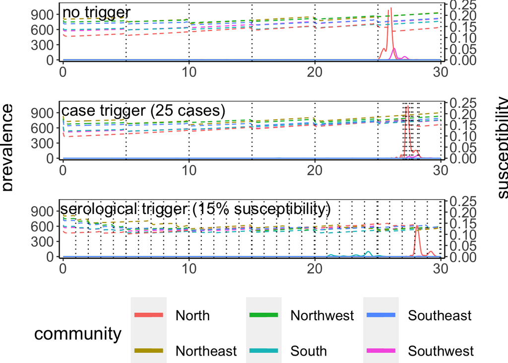

```r
typical_incidence_plot(mu=0.6, std=0)
```

Let’s plot the cumulative case burden under the different conditions:

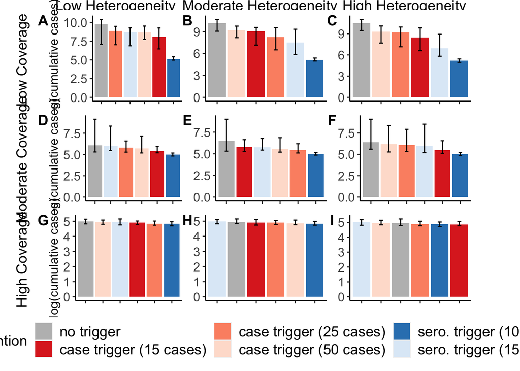

```r
barplot_cum_cases(low=0.30, high=0.70)
```

Let’s consider the worst case:

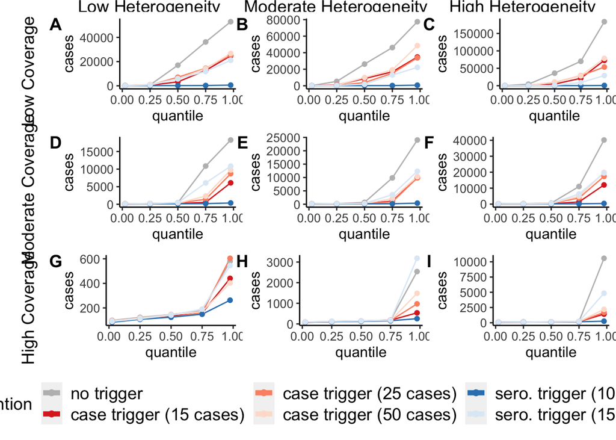

```r
worstcase_plot()
```

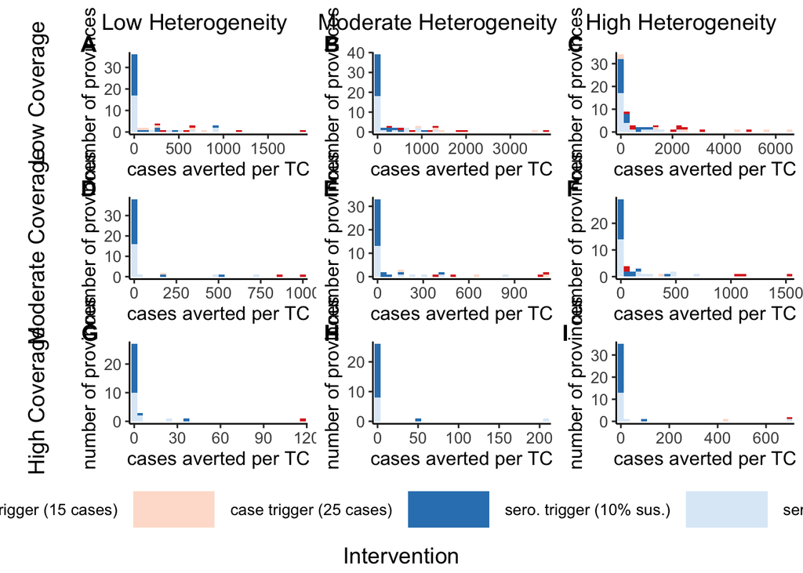

```r
province_cum_cases_plot()
```

Let’s have a look at the economic cost curves for `mu=0.6`:

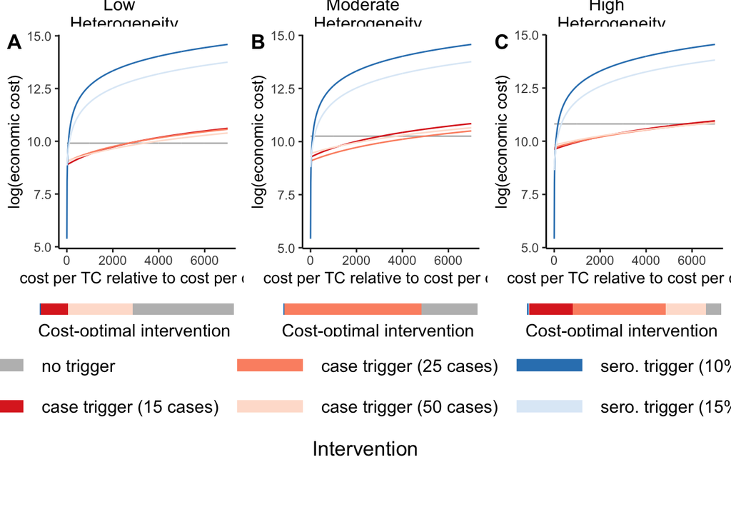

```r
relative_cost_plot(0.6)
```

Let’s have a look at the violin plots for cumulative case burden under different interventions and different scenarios:

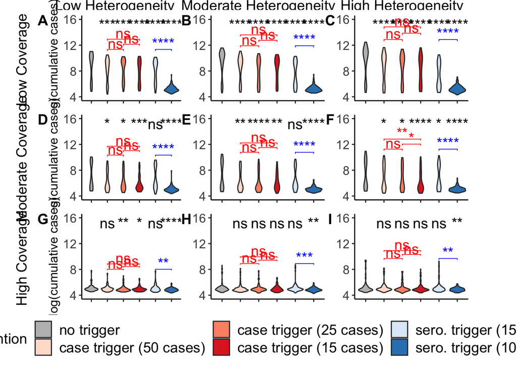

```r
violinplot_mean_cum_cases()
```